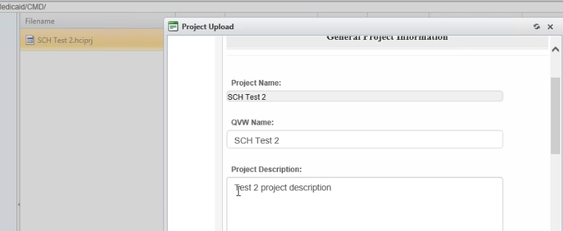

1. The **Project Description** actually appears on the **Web Portal**.

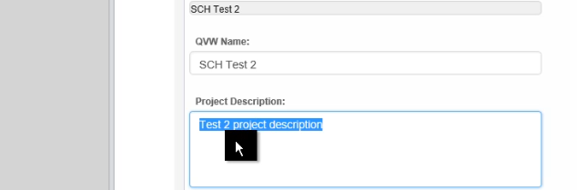

1. **Project Notes** is a field to add notes. **Project Tooltip** also appears in the **Web Portal** and provides the **User** with additional information when you mouse-over the **Report**.

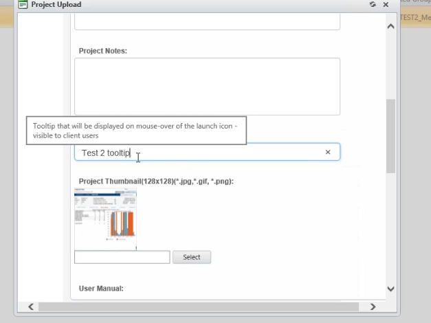

1. The **Thumbnail** is a miniature picture of the project in either .jpg, .gif or .png format.
2. There is a place mark currently for a User Guide link titled **User Manual**.

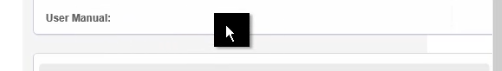

1. At the bottom of the box is a list of the **Groups**. As seen previously, our group was checked automatically since it was **Imported**. However, you can edit any of the information in this dialogue box as needed and hit the **Save** button. The new information will be updated in the SCH Test2.hciprj.

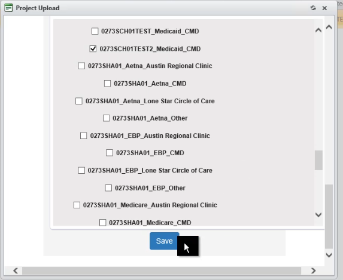

1. Next is the menu item **Reset Project**. This setting takes the project you have on the **Local** machine and will reset the content to match what is on the **Production** machine.

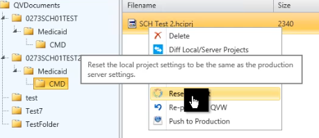

1. The reason for this setting is that, with more complex postings, things can go wrong and the **Project Management Console** goes out-of-synch from what is on the **Production** machine. At this point, you have the option to reset what is on the **Local** machine to match the content on the **Production** machine, which is the “source of Truth.”
2. When you hit the **Reset Project** button, you will have a chance to do the reset or cancel.

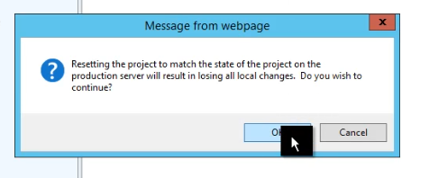

A reset process looks like this:

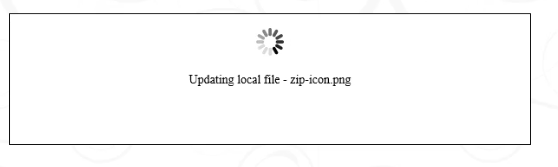

This is the reset confirmation:

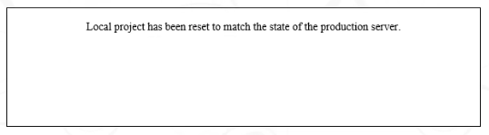

1. The next option is **Re-populate QVW.**

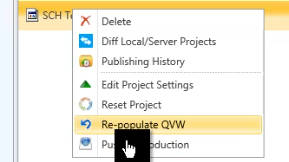

1. When you **Re-populate QVW**, the box appears and allows you to create a new report. It also gives you the option to add a **User Manual**.

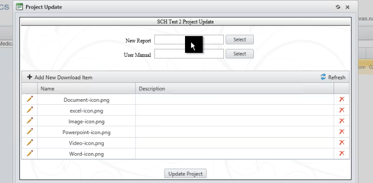

1. Ignore the section called **Add New Download Items.** It will be going away in future releases of the PMC.
2. Once you have the information you need, you hit the **Update Project** button. And you will receive a confirmation message.

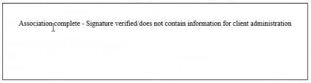

1. Since **can_emit** in the **Signature** is set to False, all **Users** will see all the data all the time and there is nothing else for the PMC to do other than associate the **Report**.
2. Next you hit **Push** and the **Report** show up. You then verify that all the information is correct.

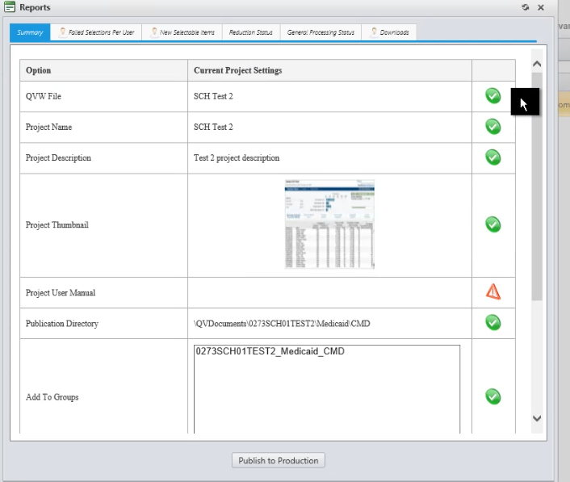

1. The tabs on the top of this screen deal with **Reduction** and will be discussed in a future release of the User Guide.
2. Everything that has been done up to this point is all local until you hit the **Publish to Production** button at the bottom of the screen.

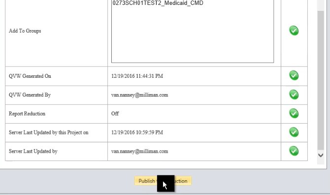

1. This takes what is **Local** and moves it to the **Production** machine. It re- associates things and moves them to the server.

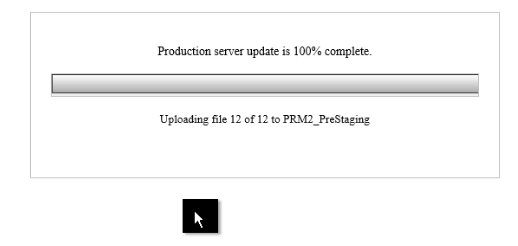

1. When complete you receive a confirmation message.

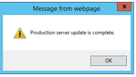